# Part I - (Loan Data from Prosper)

## Introduction

> This data set contains 113,937 loans with 81 variables on each loan, including loan amount, borrower rate (or interest rate), current loan status, borrower income, and many others.

To undertand the data variables, please visit this link https://docs.google.com/spreadsheets/d/1gDyi_L4UvIrLTEC6Wri5nbaMmkGmLQBk-Yx3z0XDEtI/edit#gid=0

## Preliminary Wrangling

The goal of this data exploration is to provide substantial answers to the following questions

- What are the factors that affect a loan's outcome status?
- What affect the borrower's APR or interest rate?
- Are there differences bbetween loans depending on how large the original loan amount was?

```python
# import all packages and set plots to be embedded inline
import numpy as np
import pandas as pd
import matplotlib.pyplot as plt
import seaborn as sns
%matplotlib inline
import warnings
warnings.filterwarnings("ignore")
```

```python
# We now load our datasets
data = pd.read_csv("prosperLoanData.csv")
```

```python
# assess the data using the data.head method

data.head()
```

|  | ListingKey | ListingNumber | ListingCreationDate | CreditGrade | Term | LoanStatus | ClosedDate | BorrowerAPR | BorrowerRate | LenderYield | ... | LP_ServiceFees | LP_CollectionFees | LP_GrossPrincipalLoss | LP_NetPrincipalLoss | LP_NonPrincipalRecoverypayments | PercentFunded | Recommendations | InvestmentFromFriendsCount | InvestmentFromFriendsAmount | Investors |
| --- | --- | --- | --- | --- | --- | --- | --- | --- | --- | --- | --- | --- | --- | --- | --- | --- | --- | --- | --- | --- | --- |
| 0 | 1021339766868145413AB3B | 193129 | 2007-08-26 19:09:29.263000000 | C | 36 | Completed | 2009-08-14 00:00:00 | 0.16516 | 0.1580 | 0.1380 | ... | -133.18 | 0.0 | 0.0 | 0.0 | 0.0 | 1.0 | 0 | 0 | 0.0 | 258 |
| 1 | 10273602499503308B223C1 | 1209647 | 2014-02-27 08:28:07.900000000 | NaN | 36 | Current | NaN | 0.12016 | 0.0920 | 0.0820 | ... | 0.00 | 0.0 | 0.0 | 0.0 | 0.0 | 1.0 | 0 | 0 | 0.0 | 1 |
| 2 | 0EE9337825851032864889A | 81716 | 2007-01-05 15:00:47.090000000 | HR | 36 | Completed | 2009-12-17 00:00:00 | 0.28269 | 0.2750 | 0.2400 | ... | -24.20 | 0.0 | 0.0 | 0.0 | 0.0 | 1.0 | 0 | 0 | 0.0 | 41 |
| 3 | 0EF5356002482715299901A | 658116 | 2012-10-22 11:02:35.010000000 | NaN | 36 | Current | NaN | 0.12528 | 0.0974 | 0.0874 | ... | -108.01 | 0.0 | 0.0 | 0.0 | 0.0 | 1.0 | 0 | 0 | 0.0 | 158 |
| 4 | 0F023589499656230C5E3E2 | 909464 | 2013-09-14 18:38:39.097000000 | NaN | 36 | Current | NaN | 0.24614 | 0.2085 | 0.1985 | ... | -60.27 | 0.0 | 0.0 | 0.0 | 0.0 | 1.0 | 0 | 0 | 0.0 | 20 |

5 rows × 81 columns

```python
#check for the shape of the data

data.shape
```

```
(113937, 81)
```

The data has 113, 937 rows and 81 columns

```python
# Let's check for the columns of the dataset
data.columns
```

```
Index(['ListingKey', 'ListingNumber', 'ListingCreationDate', 'CreditGrade',
       'Term', 'LoanStatus', 'ClosedDate', 'BorrowerAPR', 'BorrowerRate',
       'LenderYield', 'EstimatedEffectiveYield', 'EstimatedLoss',
       'EstimatedReturn', 'ProsperRating (numeric)', 'ProsperRating (Alpha)',
       'ProsperScore', 'ListingCategory (numeric)', 'BorrowerState',
       'Occupation', 'EmploymentStatus', 'EmploymentStatusDuration',
       'IsBorrowerHomeowner', 'CurrentlyInGroup', 'GroupKey',
       'DateCreditPulled', 'CreditScoreRangeLower', 'CreditScoreRangeUpper',
       'FirstRecordedCreditLine', 'CurrentCreditLines', 'OpenCreditLines',
       'TotalCreditLinespast7years', 'OpenRevolvingAccounts',
       'OpenRevolvingMonthlyPayment', 'InquiriesLast6Months', 'TotalInquiries',
       'CurrentDelinquencies', 'AmountDelinquent', 'DelinquenciesLast7Years',
       'PublicRecordsLast10Years', 'PublicRecordsLast12Months',
       'RevolvingCreditBalance', 'BankcardUtilization',
       'AvailableBankcardCredit', 'TotalTrades',
       'TradesNeverDelinquent (percentage)', 'TradesOpenedLast6Months',
       'DebtToIncomeRatio', 'IncomeRange', 'IncomeVerifiable',
       'StatedMonthlyIncome', 'LoanKey', 'TotalProsperLoans',
       'TotalProsperPaymentsBilled', 'OnTimeProsperPayments',
       'ProsperPaymentsLessThanOneMonthLate',
       'ProsperPaymentsOneMonthPlusLate', 'ProsperPrincipalBorrowed',
       'ProsperPrincipalOutstanding', 'ScorexChangeAtTimeOfListing',
       'LoanCurrentDaysDelinquent', 'LoanFirstDefaultedCycleNumber',
       'LoanMonthsSinceOrigination', 'LoanNumber', 'LoanOriginalAmount',
       'LoanOriginationDate', 'LoanOriginationQuarter', 'MemberKey',
       'MonthlyLoanPayment', 'LP_CustomerPayments',
       'LP_CustomerPrincipalPayments', 'LP_InterestandFees', 'LP_ServiceFees',
       'LP_CollectionFees', 'LP_GrossPrincipalLoss', 'LP_NetPrincipalLoss',
       'LP_NonPrincipalRecoverypayments', 'PercentFunded', 'Recommendations',
       'InvestmentFromFriendsCount', 'InvestmentFromFriendsAmount',
       'Investors'],
      dtype='object')
```

From the assessment, I have selected only columns that are useful for our analysis out of the 81 columns to use in my analysis. This columns is relevant to answering the questions above.

```python
# LEts now save the save the columns in a new dataframe we will be using for our analysis.

df = data.loc[:, ['ListingCreationDate', 'Term', 'LoanStatus', 'ClosedDate', 'BorrowerAPR',
                         'BorrowerRate', 'LenderYield', 'ProsperRating (Alpha)', 'ProsperScore',
                  'ListingCategory (numeric)',
                         'BorrowerState', 'Occupation', 'EmploymentStatus', 'AmountDelinquent',
                         'IncomeRange', 'StatedMonthlyIncome',
                         'LoanCurrentDaysDelinquent',
                         'LoanOriginalAmount', 'LoanOriginationDate',
                         'MonthlyLoanPayment', 'LP_ServiceFees', 'Investors']]
```

```python
df.head()
```

|  | ListingCreationDate | Term | LoanStatus | ClosedDate | BorrowerAPR | BorrowerRate | LenderYield | ProsperRating (Alpha) | ProsperScore | ListingCategory (numeric) | ... | EmploymentStatus | AmountDelinquent | IncomeRange | StatedMonthlyIncome | LoanCurrentDaysDelinquent | LoanOriginalAmount | LoanOriginationDate | MonthlyLoanPayment | LP_ServiceFees | Investors |
| --- | --- | --- | --- | --- | --- | --- | --- | --- | --- | --- | --- | --- | --- | --- | --- | --- | --- | --- | --- | --- | --- |
| 0 | 2007-08-26 19:09:29.263000000 | 36 | Completed | 2009-08-14 00:00:00 | 0.16516 | 0.1580 | 0.1380 | NaN | NaN | 0 | ... | Self-employed | 472.0 | $25,000-49,999 | 3083.333333 | 0 | 9425 | 2007-09-12 00:00:00 | 330.43 | -133.18 | 258 |
| 1 | 2014-02-27 08:28:07.900000000 | 36 | Current | NaN | 0.12016 | 0.0920 | 0.0820 | A | 7.0 | 2 | ... | Employed | 0.0 | $50,000-74,999 | 6125.000000 | 0 | 10000 | 2014-03-03 00:00:00 | 318.93 | 0.00 | 1 |
| 2 | 2007-01-05 15:00:47.090000000 | 36 | Completed | 2009-12-17 00:00:00 | 0.28269 | 0.2750 | 0.2400 | NaN | NaN | 0 | ... | Not available | NaN | Not displayed | 2083.333333 | 0 | 3001 | 2007-01-17 00:00:00 | 123.32 | -24.20 | 41 |
| 3 | 2012-10-22 11:02:35.010000000 | 36 | Current | NaN | 0.12528 | 0.0974 | 0.0874 | A | 9.0 | 16 | ... | Employed | 10056.0 | $25,000-49,999 | 2875.000000 | 0 | 10000 | 2012-11-01 00:00:00 | 321.45 | -108.01 | 158 |
| 4 | 2013-09-14 18:38:39.097000000 | 36 | Current | NaN | 0.24614 | 0.2085 | 0.1985 | D | 4.0 | 2 | ... | Employed | 0.0 | $100,000+ | 9583.333333 | 0 | 15000 | 2013-09-20 00:00:00 | 563.97 | -60.27 | 20 |

5 rows × 22 columns

```python
df.shape
```

```
(113937, 22)
```

```python
df.info()
```

```
<class 'pandas.core.frame.DataFrame'>
RangeIndex: 113937 entries, 0 to 113936
Data columns (total 22 columns):
 #   Column                     Non-Null Count   Dtype
---  ------                     --------------   -----
 0   ListingCreationDate        113937 non-null  object
 1   Term                       113937 non-null  int64
 2   LoanStatus                 113937 non-null  object
 3   ClosedDate                 55089 non-null   object
 4   BorrowerAPR                113912 non-null  float64
 5   BorrowerRate               113937 non-null  float64
 6   LenderYield                113937 non-null  float64
 7   ProsperRating (Alpha)      84853 non-null   object
 8   ProsperScore               84853 non-null   float64
 9   ListingCategory (numeric)  113937 non-null  int64
 10  BorrowerState              108422 non-null  object
 11  Occupation                 110349 non-null  object
 12  EmploymentStatus           111682 non-null  object
 13  AmountDelinquent           106315 non-null  float64
 14  IncomeRange                113937 non-null  object
 15  StatedMonthlyIncome        113937 non-null  float64
 16  LoanCurrentDaysDelinquent  113937 non-null  int64
 17  LoanOriginalAmount         113937 non-null  int64
 18  LoanOriginationDate        113937 non-null  object
 19  MonthlyLoanPayment         113937 non-null  float64
 20  LP_ServiceFees             113937 non-null  float64
 21  Investors                  113937 non-null  int64
dtypes: float64(8), int64(5), object(9)
memory usage: 19.1+ MB
```

```python
df.duplicated().sum()
```

```
0
```

```python
#change date coulums to datetime datatype

#Adjust Datetime columns
df['ListingCreationDate'] = pd.to_datetime(df['ListingCreationDate'])
df['ClosedDate'] = pd.to_datetime(df['ClosedDate'])
df['LoanOriginationDate'] = pd.to_datetime(df['LoanOriginationDate'])
```

```python
df.info()
```

```
<class 'pandas.core.frame.DataFrame'>
RangeIndex: 113937 entries, 0 to 113936
Data columns (total 22 columns):
 #   Column                     Non-Null Count   Dtype
---  ------                     --------------   -----
 0   ListingCreationDate        113937 non-null  datetime64[ns]
 1   Term                       113937 non-null  int64
 2   LoanStatus                 113937 non-null  object
 3   ClosedDate                 55089 non-null   datetime64[ns]
 4   BorrowerAPR                113912 non-null  float64
 5   BorrowerRate               113937 non-null  float64
 6   LenderYield                113937 non-null  float64
 7   ProsperRating (Alpha)      84853 non-null   object
 8   ProsperScore               84853 non-null   float64
 9   ListingCategory (numeric)  113937 non-null  int64
 10  BorrowerState              108422 non-null  object
 11  Occupation                 110349 non-null  object
 12  EmploymentStatus           111682 non-null  object
 13  AmountDelinquent           106315 non-null  float64
 14  IncomeRange                113937 non-null  object
 15  StatedMonthlyIncome        113937 non-null  float64
 16  LoanCurrentDaysDelinquent  113937 non-null  int64
 17  LoanOriginalAmount         113937 non-null  int64
 18  LoanOriginationDate        113937 non-null  datetime64[ns]
 19  MonthlyLoanPayment         113937 non-null  float64
 20  LP_ServiceFees             113937 non-null  float64
 21  Investors                  113937 non-null  int64
dtypes: datetime64[ns](3), float64(8), int64(5), object(6)
memory usage: 19.1+ MB
```

```python
#Change the datatype for all other categorical columns to category datatype
df['Occupation'] = df['Occupation'].astype('category')
df['BorrowerState'] = df['BorrowerState'].astype('category')
df['LoanStatus'] = df['LoanStatus'].astype('category')
df['ListingCategory (numeric)'] = df['ListingCategory (numeric)'].astype('category')
df['EmploymentStatus'] = df['EmploymentStatus'].astype('category')
```

```python
df.info()
```

```
<class 'pandas.core.frame.DataFrame'>
RangeIndex: 113937 entries, 0 to 113936
Data columns (total 22 columns):
 #   Column                     Non-Null Count   Dtype
---  ------                     --------------   -----
 0   ListingCreationDate        113937 non-null  datetime64[ns]
 1   Term                       113937 non-null  int64
 2   LoanStatus                 113937 non-null  category
 3   ClosedDate                 55089 non-null   datetime64[ns]
 4   BorrowerAPR                113912 non-null  float64
 5   BorrowerRate               113937 non-null  float64
 6   LenderYield                113937 non-null  float64
 7   ProsperRating (Alpha)      84853 non-null   object
 8   ProsperScore               84853 non-null   float64
 9   ListingCategory (numeric)  113937 non-null  category
 10  BorrowerState              108422 non-null  category
 11  Occupation                 110349 non-null  category
 12  EmploymentStatus           111682 non-null  category
 13  AmountDelinquent           106315 non-null  float64
 14  IncomeRange                113937 non-null  object
 15  StatedMonthlyIncome        113937 non-null  float64
 16  LoanCurrentDaysDelinquent  113937 non-null  int64
 17  LoanOriginalAmount         113937 non-null  int64
 18  LoanOriginationDate        113937 non-null  datetime64[ns]
 19  MonthlyLoanPayment         113937 non-null  float64
 20  LP_ServiceFees             113937 non-null  float64
 21  Investors                  113937 non-null  int64
dtypes: category(5), datetime64[ns](3), float64(8), int64(4), object(2)
memory usage: 15.3+ MB
```

```python
# Change ProsperRating & IncomeRange to ordinal categorical
ordinal_cat = {'ProsperRating (Alpha)': ['N/A','HR','E','D','C', 'B', 'A', 'AA'],
                    'IncomeRange':['$0','$1-24,999','$25,000-49,999','$50,000-74,999','$75,000-99,999','$100,000+']}
for i in ordinal_cat:
    ordered_col = pd.api.types.CategoricalDtype(ordered = True, categories = ordinal_cat[i])
    df[i] = df[i].astype(ordered_col)
```

```python
df['ProsperRating (Alpha)'].value_counts()
```

```
C      18345
B      15581
A      14551
D      14274
E       9795
HR      6935
AA      5372
N/A        0
Name: ProsperRating (Alpha), dtype: int64
```

```python
df['IncomeRange'].value_counts()
```

```
$25,000-49,999    32192
$50,000-74,999    31050
$100,000+         17337
$75,000-99,999    16916
$1-24,999          7274
$0                  621
Name: IncomeRange, dtype: int64
```

```python
df['Occupation'].value_counts()
```

```
Other                          28617
Professional                   13628
Computer Programmer             4478
Executive                       4311
Teacher                         3759
                               ...
Dentist                           68
Student - College Freshman        41
Student - Community College       28
Judge                             22
Student - Technical School        16
Name: Occupation, Length: 67, dtype: int64
```

```python
df.shape
```

```
(113937, 22)
```

### What is the structure of your dataset?

The data set has 22 columns and 113,937 rows. it has no duplicate values. But, it has some null valuse in about 7 coulumns. We will ignore the fixing of the null values for now. The data contain different kinds of data types like the numeric, category, strings and datetime datatypes.

### What is/are the main feature(s) of interest in your dataset?

- Borrower Rate
- Borrower APR
- Prosper Score
- Credit Score
- Original Loan Amount
- Monthly Payment
- Borrower Occupation
- Borrower State

I will also look at featurea like LoanOriginationDate and LenderYield

### What features in the dataset do you think will help support your investigation into your feature(s) of interest?

Loan Status and Employment Status will have a strong correlation on loan and the features we are trying to investigate.

## Univariate Exploration

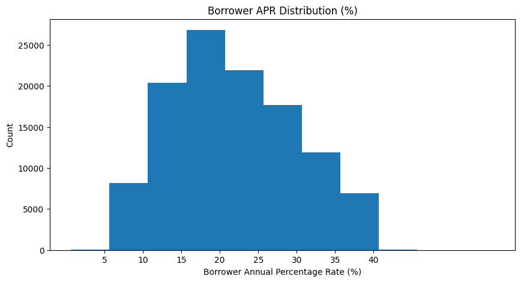

```python
# Dist of Borrower APR in %
binsize = 5
borrowe_APR_percentage = df['BorrowerAPR']*100
bins = np.arange(df['BorrowerAPR'].min()*100, df['BorrowerAPR'].max()*100+binsize, binsize)

plt.figure(figsize=[10, 5])
plt.hist(x = borrowe_APR_percentage, bins = bins)
plt.title('Borrower APR Distribution (%)')
plt.xlabel('Borrower Annual Percentage Rate (%)')
plt.ylabel('Count')
plt.xticks([5, 10, 15, 20, 25, 30, 35, 40], ['5','10', '15', '20', '25', '30', '35', '40'])
plt.show()
```

Notice that the Borrowner's APR is almmost normally distributed with 15-20% peak

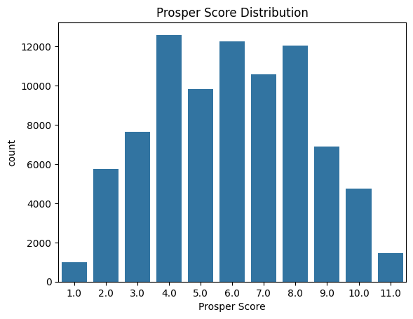

```python
#Prosper Score Distribution (range form 1 to 10)
base_color = sns.color_palette()[0]
sns.countplot(data=df, x= 'ProsperScore', color=base_color)
plt.title('Prosper Score Distribution')
plt.xlabel('Prosper Score')
```

Proper scores are also almost normally distributed, with 4,5,6,7,8 as the most scores and 4 is the highest proper score

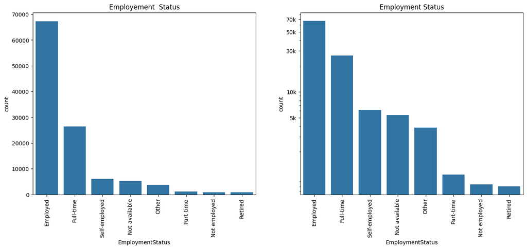

```python
plt.figure(figsize=[16,6])
default_color = sns.color_palette()[0]
plt.subplot(1,2,1)
sns.countplot(data = df, x = 'EmploymentStatus', color = default_color, order = df['EmploymentStatus'].value_counts().index);
plt.title("Employement  Status")
# plt.yscale('log')
# plt.yticks([10, 1e2, 1e3, 1e4], [10, 100, '1k', '10k'])
plt.xticks(rotation =90);

plt.subplot(1,2,2)
sns.countplot(data = df, x = 'EmploymentStatus', color = default_color, order = df['EmploymentStatus'].value_counts().index);
plt.title("Employment Status")
plt.yscale('log')
plt.yticks([5e3, 10e3, 30e3, 50e3,70e3], ['5k','10k', '30k', '50k', '70k'])
plt.xticks(rotation =90);
```

This shows that the borrowers which are employed tends to be of higher proportion than others

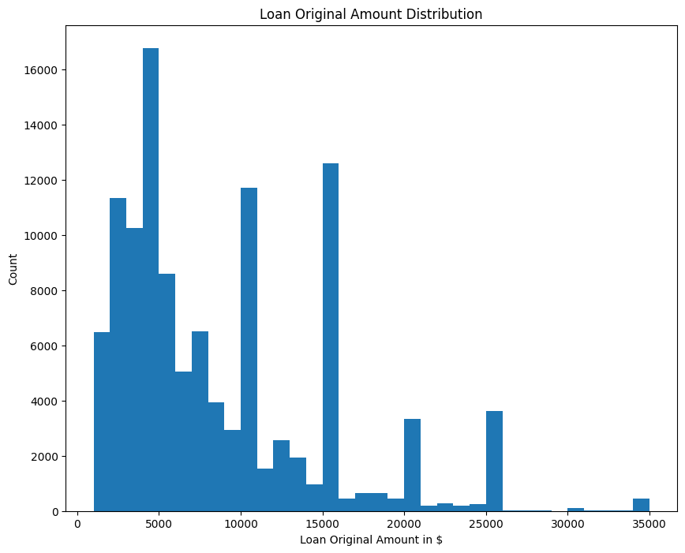

```python
# Loan Original Amt Dis
binsize = 1000
bins = np.arange(df['LoanOriginalAmount'].min(), df['LoanOriginalAmount'].max()+binsize, binsize)

plt.figure(figsize=[10, 8])
plt.hist(data = df, x = 'LoanOriginalAmount', bins = bins)
plt.title('Loan Original Amount Distribution')
plt.xlabel('Loan Original Amount in $')
plt.ylabel('Count')
plt.show()
```

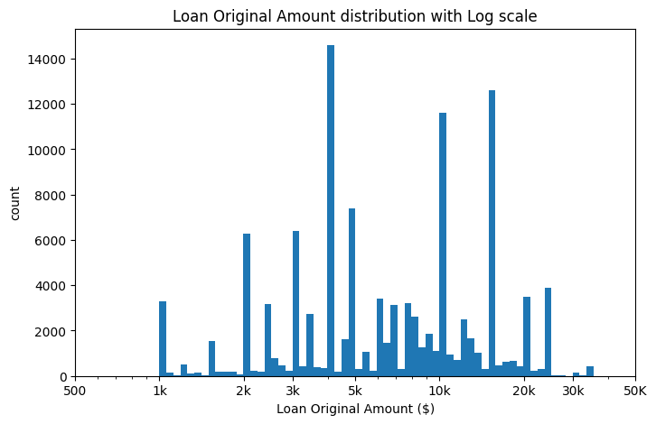

```python
# Putting Loan Original Amount in a log-scale
log_binsize = 0.025
bins = 10 ** np.arange(3, np.log10(df['LoanOriginalAmount'].max())+log_binsize, log_binsize)
plt.figure(figsize=[8, 5])
plt.hist(data = df, x = 'LoanOriginalAmount', bins = bins)
plt.title('Loan Original Amount distribution with Log scale')
plt.xscale('log')
plt.xticks([500, 1e3, 2e3,3e3, 5e3, 1e4, 2e4, 3e4, 5e4], ['500', '1k', '2k', '3k', '5k', '10k', '20k', '30k', '50K'])
plt.xlabel('Loan Original Amount ($)')
plt.ylabel('count')
plt.show()
```

- The highest value for original loan amount is between 3K and 5K. I also notice a significant increase in amount between 10K and 20K

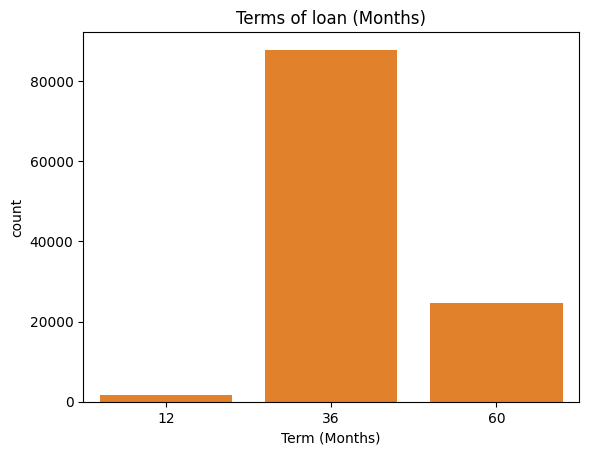

```python
base_color = sns.color_palette()[1]
sns.countplot(data=df, x= 'Term',color=base_color);
plt.title('Terms of loan (Months)')
plt.xlabel('Term (Months)');
```

> we notice that most of the values are in the 3 years (36 months)

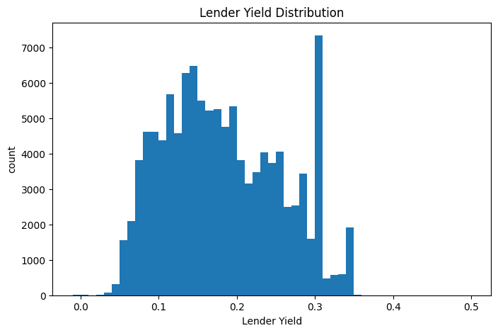

```python
#Lender Yield Distribution
binsize = 0.01
bins = np.arange(df['LenderYield'].min(), df['LenderYield'].max()+binsize, binsize)

plt.figure(figsize=[8, 5])
plt.hist(data = df, x = 'LenderYield', bins = bins)
plt.xlabel('Lender Yield')
plt.title('Lender Yield Distribution')
plt.ylabel('count')
plt.show()
```

> we notice LenderYield is nomarlly distributed and has most of its the values between 0.1 and 0.2 and we notice an increase at 0.3

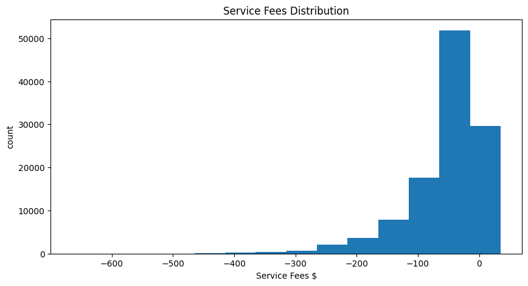

```python
# Service Fees Distribution
binsize = 50
bins = np.arange(df['LP_ServiceFees'].min(), df['LP_ServiceFees'].max()+binsize, binsize)

plt.figure(figsize=[10, 5])
plt.hist(data = df, x = 'LP_ServiceFees', bins = bins)
plt.xlabel('Service Fees $')
plt.title('Service Fees Distribution')
plt.ylabel('count')
plt.show()
```

> We see that service fees are left skewed but we can't put it in the log scale because of the negative values.

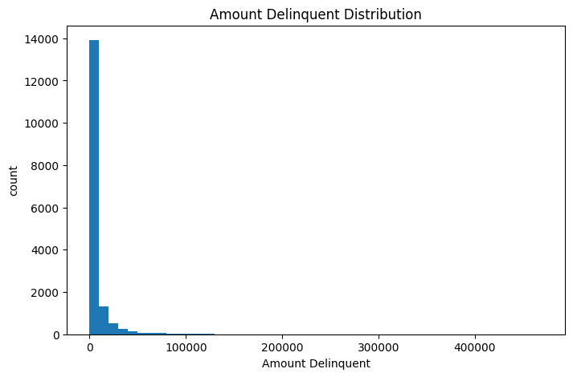

```python
#Amount Delinquent Distribution
binsize = 10000
bins = np.arange(df['AmountDelinquent'].min(), df['AmountDelinquent'].max()+binsize, binsize)

plt.figure(figsize=[8, 5])
plt.hist(data = df[df['AmountDelinquent']>0], x = 'AmountDelinquent', bins = bins)
plt.title('Amount Delinquent Distribution')
plt.xlabel('Amount Delinquent')
plt.ylabel('count')
plt.show()
```

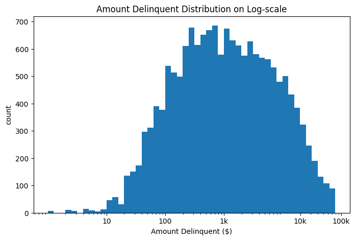

```python
#Amount Delinquent Distribution on a log scale

log_binsize = 0.1
bins = 10 ** np.arange(0,5, log_binsize)

plt.figure(figsize=[8, 5])
plt.hist(data = df, x = 'AmountDelinquent', bins = bins)
plt.title('Amount Delinquent Distribution on Log-scale')
plt.xscale('log')
plt.xticks([1e1, 1e2, 1e3, 2e4, 1e5], ['10', '100', '1k', '10k', '100k'])
plt.xlabel('Amount Delinquent ($)')
plt.ylabel('count')
plt.show()
```

- It is obvious that most amounts delinquent falls around $1000 and it is normally distibuted

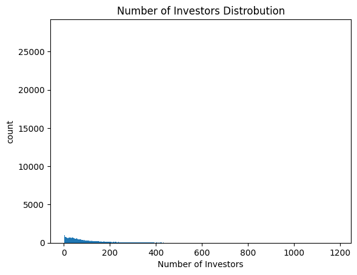

```python
#Number of Investors Distrobution
binsize = 1
bins = np.arange(df['Investors'].min(), df['Investors'].max()+binsize, binsize)

#plt.figure(figsize=[8, 5])
plt.hist(data = df[df['Investors'] > 0], x = 'Investors', bins = bins)
plt.xlabel('Number of Investors')
plt.title('Number of Investors Distrobution')
plt.ylabel('count')
plt.show()
```

- We can't see this distribution well so let's try log scale as it may work better

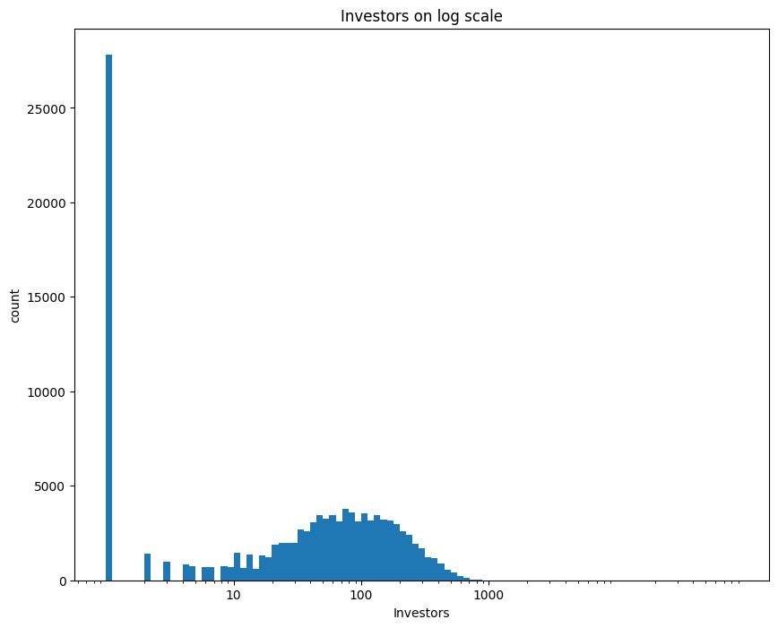

```python
#Number of Investors Distrobution on log scale for all loans
log_binsize = 0.05
bins = 10 ** np.arange(0, 5, log_binsize)

plt.figure(figsize=[10, 8])
plt.hist(data = df, x = 'Investors', bins = bins)
plt.title('Investors on log scale')
plt.xscale('log')
plt.xticks([1e1, 1e2, 1e3], ['10', '100', '1000'])
plt.xlabel('Investors')
plt.ylabel('count')
plt.show()
```

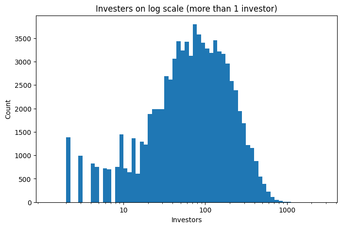

```python
#We can plot the same for only loans with more than 1 investor
log_binsize = 0.05
bins = 10 ** np.arange(0.1, 3.5, log_binsize)

plt.figure(figsize=[8, 5])
plt.hist(data = df, x = 'Investors', bins = bins)
plt.title('Investers on log scale (more than 1 investor)')
plt.xscale('log')
plt.xticks([1e1, 1e2, 1e3], ['10', '100', '1000'])
plt.xlabel('Investors')
plt.ylabel('Count')
plt.show()
```

- Number of investors (for data with number of inestoers more than 1) is almost normally distributed around 100 and that was expected from the previce one

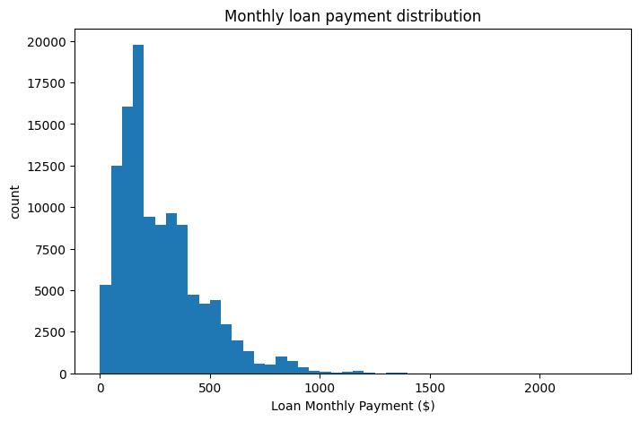

```python
# Monthly loan payment distribution
binsize = 50
bins = np.arange(0, df['MonthlyLoanPayment'].max()+binsize, binsize)

plt.figure(figsize=[8, 5])
plt.hist(data = df, x = 'MonthlyLoanPayment', bins = bins)
plt.xlabel('Loan Monthly Payment ($)')
plt.ylabel('count')
plt.title('Monthly loan payment distribution')
plt.show()
```

- There's a long tail in the distribution, so let's put it on a log scale instead

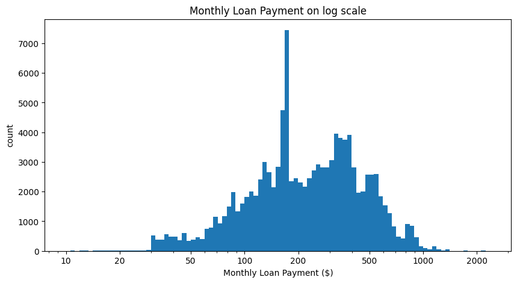

```python
# Using log-scale
log_binsize = 0.025
bins = 10 ** np.arange(1, np.log10(df['MonthlyLoanPayment'].max())+log_binsize, log_binsize)

plt.figure(figsize=[10, 5])
plt.hist(data = df, x = 'MonthlyLoanPayment', bins = bins)
plt.xscale('log')
plt.xticks([10, 20, 50, 100, 200, 500, 1e3, 2e3], ['10', '20','50', '100', '200', '500', '1000', '2000'])
plt.xlabel('Monthly Loan Payment ($)')
plt.ylabel('count')
plt.title('Monthly Loan Payment on log scale')
plt.show()
```

- The is normally distributed with the peak between 100 and 200 and some increase at the 500

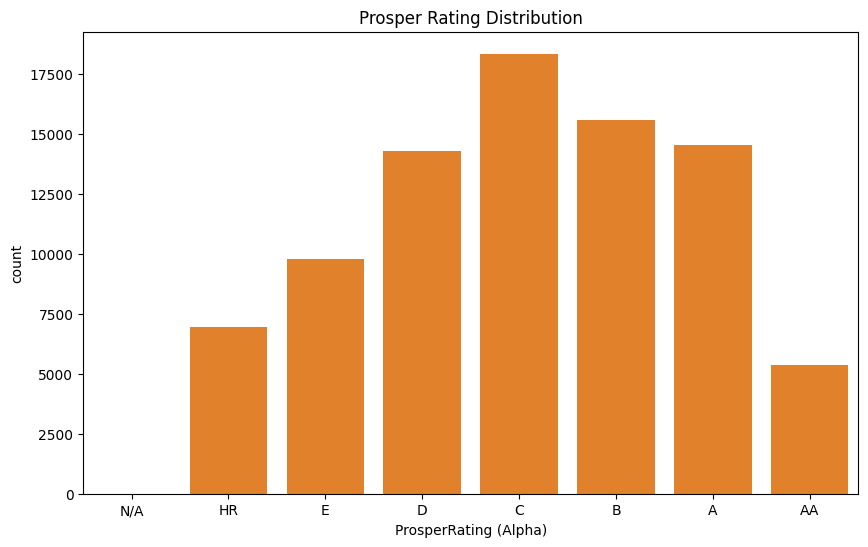

```python
# Prosper Rating Distribution

plt.figure(figsize=[10, 6]);
sns.countplot(data=df,x='ProsperRating (Alpha)',color=base_color);
plt.title('Prosper Rating Distribution');
```

- Most borrowers get Prosper Rating of 'C'

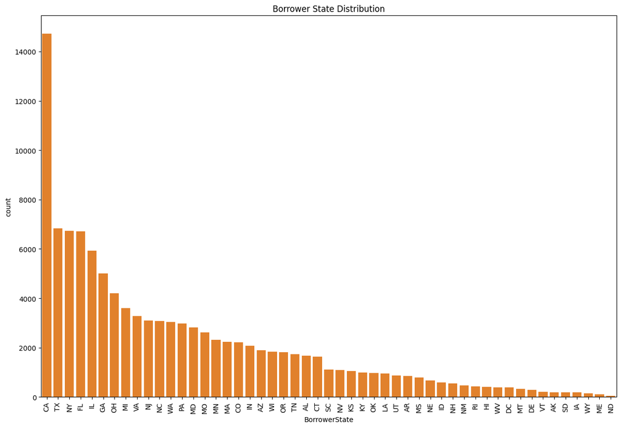

```python
#Borrower State Distrobution
cat_order = df['BorrowerState'].value_counts().index
plt.figure(figsize=[15, 10])
sns.countplot(data=df,x='BorrowerState',color=base_color, order=cat_order);
plt.title('Borrower State Distribution');
plt.xticks(rotation=90);
```

- We can see that California (CA), Texas (TX) and New York (NY) have the 3 biggest numbers of loans originated in that period of time.

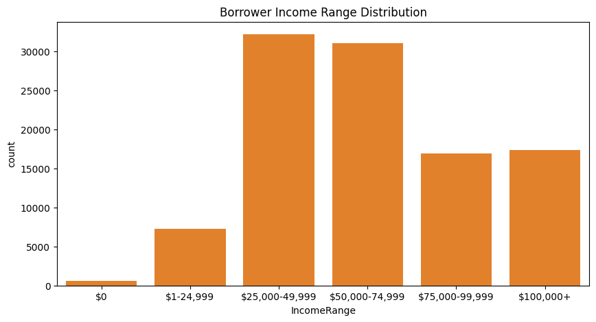

```python
#Borrower Income Range Status Distrobution
plt.figure(figsize=[10, 5])
sns.countplot(data=df,x='IncomeRange',color=base_color);
plt.title('Borrower Income Range Distribution')
```

- We can see that people with income range of $25,000-49,999 are the ones who are taking loans most

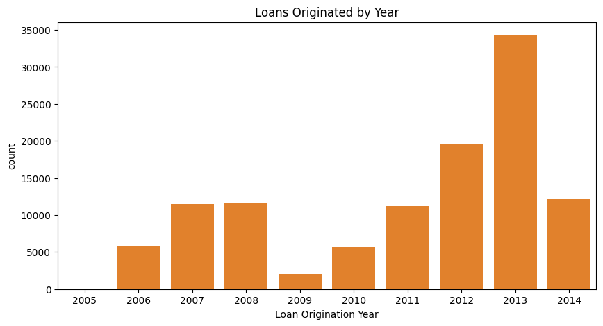

```python
# Loan Origination by Year
plt.figure(figsize=[10, 5])
sns.countplot(data=df,x=df['LoanOriginationDate'].dt.year,color=base_color)
plt.title('Loans Originated by Year')
plt.xlabel('Loan Origination Year');
```

- We can see that there is a drop in 2009 in loans but it started to increase gradually and reached it's peak at 2013

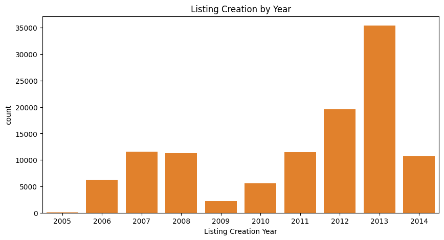

```python
# Listing Creation  by Year
plt.figure(figsize=[10, 5])
sns.countplot(data=df,x=df['ListingCreationDate'].dt.year,color=base_color)
plt.title('Listing Creation by Year')
plt.xlabel('Listing Creation Year');
```

- The same observation as the previous chart which is expected because we normally create the list every year.

### Discuss the distribution(s) of your variable(s) of interest. Were there any unusual points? Did you need to perform any transformations?

> Year 2013 had the highest loan creation. California (CA) had the biggest number of loans. Service fees was left skewed but I couldn't do the log scale because of negative values.

> Loan Original Amount distribution is right skewed and I performed log transformation on it to interpret the visualization. I also did the log transformation to these variables: Monthly Loan Payment, Investors and Amount Delinquent.

### Of the features you investigated, were there any unusual distributions? Did you perform any operations on the data to tidy, adjust, or change the form of the data? If so, why did you do this?

> Due to the high difference between AmountDelinquent values the distribution was really on large scale and I couldn't see it clear so I did the log transformation.  
> Some features had long-tailed, skewed distributions, these were checked on a log scale to show the hidden distribution in some areas.

## Bivariate Exploration

> We need to identify numerical and categorical features in order to choose the appropriate chart type to explore variables in pairs.

```python
cat_feat = ['LoanStatus', 'ProsperRating (Alpha)', 'ListingCategory (numeric)', 'BorrowerState', 'Occupation',
                         'EmploymentStatus', 'IncomeRange']
```

```python
numeric_feat = ['Term', 'BorrowerAPR', 'BorrowerRate', 'LenderYield', 'ProsperScore',
                     'StatedMonthlyIncome', 'LoanOriginalAmount', 'MonthlyLoanPayment', 'LP_ServiceFees', 'Investors',
                    'AmountDelinquent','LoanCurrentDaysDelinquent']
```

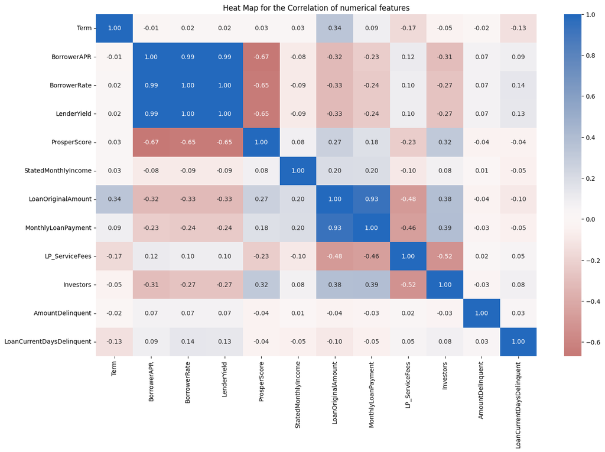

```python
# Correlation matrix for all numeric variables
plt.figure(figsize = [16, 10])
sns.heatmap(df[numeric_feat].corr(), annot = True, fmt = '.2f',
           cmap = 'vlag_r', center = 0)
plt.title('Heat Map for the Correlation of numerical features')
plt.show()
```

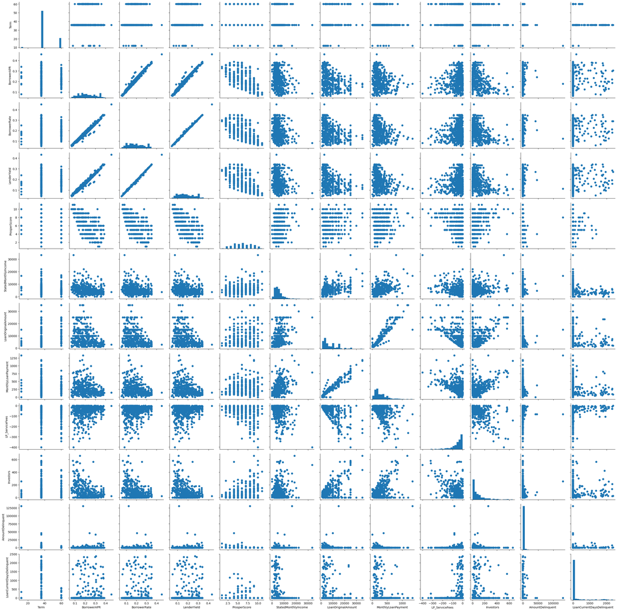

```python
# plot matrix: sample 500 loans so that plots are clearer and
# they render faster
samples = np.random.choice(df.shape[0], 500, replace = False)
df_sample = df.loc[samples,:]

g = sns.PairGrid(data = df_sample, vars = numeric_feat)
g = g.map_diag(plt.hist, bins = 20);
g.map_offdiag(plt.scatter);
```

> There is a negative coorelation between the prosper score and both the APR and lender yield. Prosper ratings and APR have a negative link, as do Prosper scores and Lender yield.

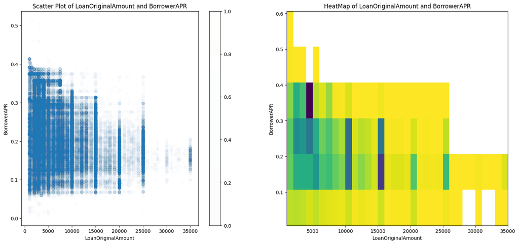

```python
plt.figure(figsize = [18, 8])
plt.subplot(1, 2, 1)
plt.scatter(data = df, x = 'LoanOriginalAmount', y = 'BorrowerAPR',  alpha =  0.01)
plt.title('Scatter Plot of LoanOriginalAmount and BorrowerAPR')
plt.xlabel('LoanOriginalAmount')
plt.ylabel('BorrowerAPR');
plt.colorbar();

plt.subplot(1, 2, 2)
bins_x = np.arange(df['LoanOriginalAmount'].min(), df['LoanOriginalAmount'].max()+1000, 1000)
bins_y = np.arange(df['BorrowerAPR'].min(), df['BorrowerAPR'].max()+0.1, 0.1)
plt.hist2d(data = df, x = 'LoanOriginalAmount', y = 'BorrowerAPR', bins = [bins_x, bins_y],
                                                                                 cmap = 'viridis_r', cmin = 0.5)
plt.title('HeatMap of LoanOriginalAmount and BorrowerAPR')
plt.xlabel('LoanOriginalAmount')
plt.ylabel('BorrowerAPR');
```

Large loans have a substantially lower annual interest rate from the borrower since there is a negative correlation between the loan's original amount and the borrower's APR.

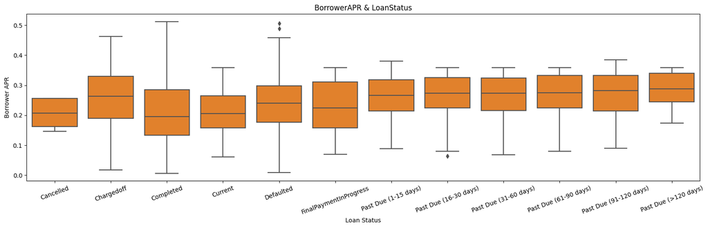

```python
# Borrower APR vs Status of Loan
plt.figure(figsize = [20, 5])
sns.boxplot(data=df,y='BorrowerAPR',x='LoanStatus',color=base_color);
plt.title('BorrowerAPR & LoanStatus');
plt.ylabel('Borrower APR');
plt.xlabel('Loan Status');
plt.xticks(rotation=20);
```

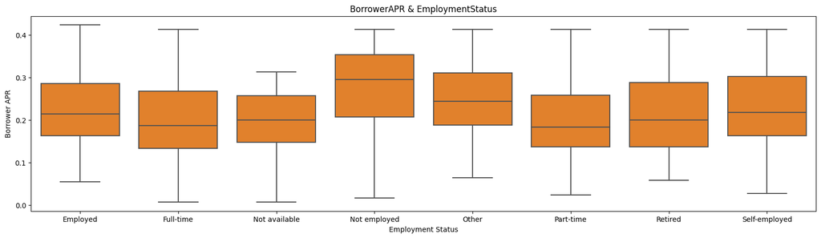

```python
# Borrower APR vs Employment status
plt.figure(figsize = [20, 5])
sns.boxplot(data=df,y='BorrowerAPR',x='EmploymentStatus',color=base_color);
plt.title('BorrowerAPR & EmploymentStatus');
plt.ylabel('Borrower APR');
plt.xlabel('Employment Status');
```

- The graph of BorrowerAPR versus LoanStatus shows that Current and Completed Loans have Lower Rate and Lower Mean than Past Due Loans.
- Working individuals have a lower IQR than those who are not employed, as shown on the graph of borrower APR vs. employment status.

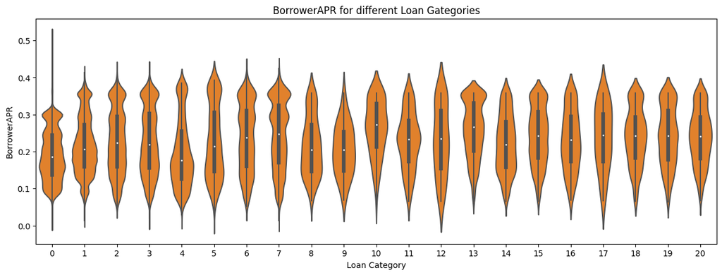

```python
plt.figure(figsize = [15, 5])
sns.violinplot(data=df,x='ListingCategory (numeric)', y='BorrowerAPR',color=base_color);
plt.title('BorrowerAPR for different Loan Gategories')
plt.xlabel('Loan Category');
plt.ylabel('BorrowerAPR');
```

- It is clear that Cosmetic Procedures have higher interest rates and that the data is evenly distributed.
- Listing Category: The grouping the borrower chose for their listing when they posted it: Not Available (0), 1 - Consolidating Debt, 2 - Improvement of the home Business, No. 3 Personal Loan #4, Student Use #5, and Auto, Other, and 6 Baby & Adoption, 8 9 - Boat, 10 Cosmetic Surgery, 11 - Ring of engagement, Green Loans (12), Household Expenses, Code 13 14 - Significant Purchases 16 - Motorcycle, 15 - Medical/Dental 17, "RV," 18, "Taxes," 19 - Vacation; 20 - Loans for a wedding

## Multivariate Exploration

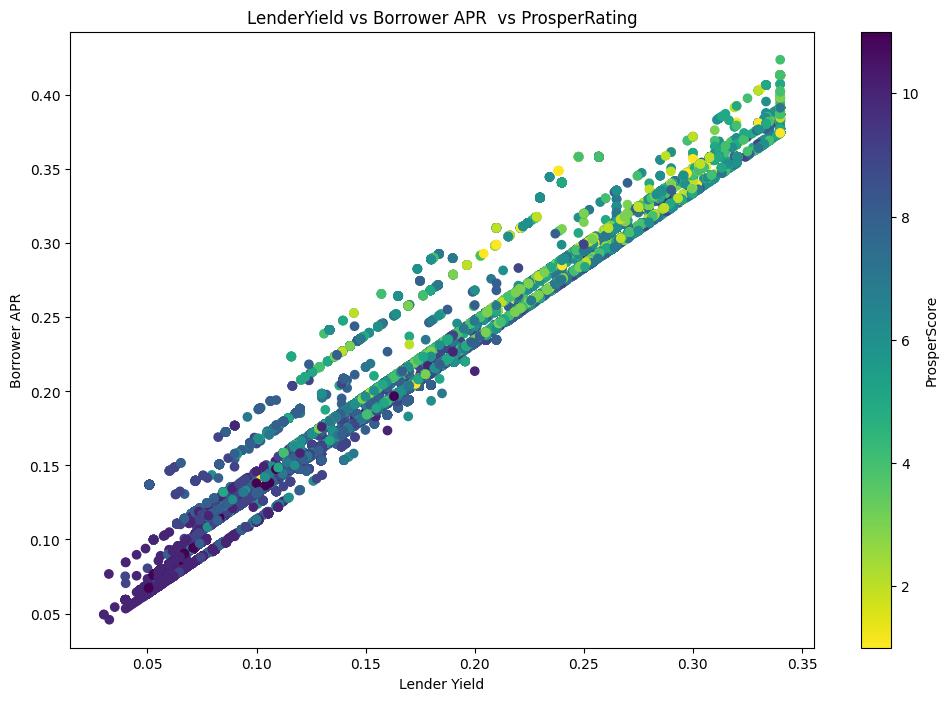

```python
# LenderYield vs Borrower APR  vs ProsperRating
plt.figure(figsize = [12, 8])
plt.scatter(data=df,x='LenderYield',y = 'BorrowerAPR',c='ProsperScore',cmap = 'viridis_r')
plt.colorbar(label = 'ProsperScore');
plt.title('LenderYield vs Borrower APR  vs ProsperRating');
plt.xlabel('Lender Yield');
plt.ylabel('Borrower APR');
```

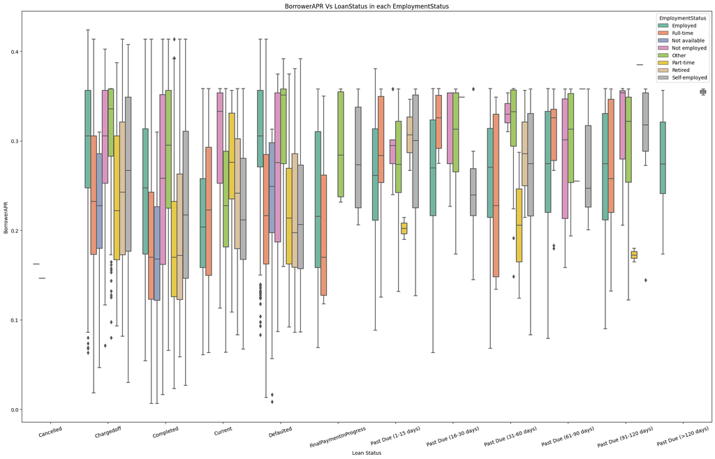

```python
# LoanStatus Vs BorrowerAPR in each EmploymentStatus
plt.figure(figsize=[25,15])
sns.boxplot(x="LoanStatus", y="BorrowerAPR", hue="EmploymentStatus", data=df, palette="Set2");
plt.title('BorrowerAPR Vs LoanStatus in each EmploymentStatus');
plt.xlabel('Loan Status');
plt.ylabel('BorrowerAPR');
plt.xticks(rotation = 18);
```

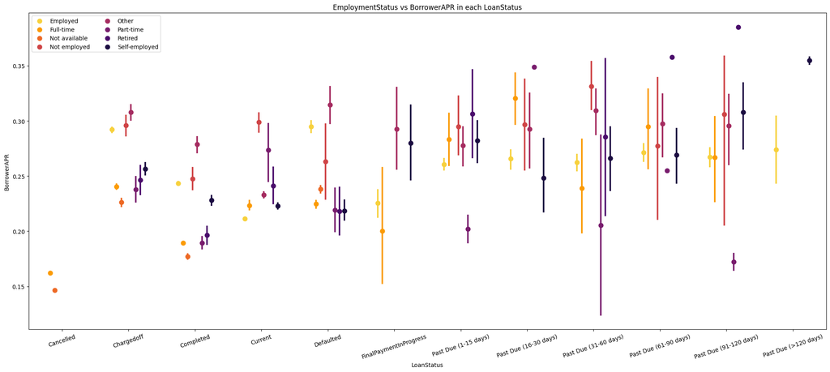

```python
# EmploymentStatus vs BorrowerAPR in each LoanStatus
fig = plt.figure(figsize = [25,10])
ax = sns.pointplot(data = df, x = 'LoanStatus', y = 'BorrowerAPR', hue = 'EmploymentStatus', linestyles = "",
                  dodge = 0.5, palette = 'inferno_r')
plt.title('EmploymentStatus vs BorrowerAPR in each LoanStatus')
plt.ylabel('BorrowerAPR')
plt.xticks(rotation=18)
plt.legend(ncol=2)
plt.show();
```

### Were there any interesting or surprising interactions between features?

ProsperScore and BorrowerAPR were discovered to be negatively correlated, as higher prosper scores indicate reduced risk associated with the loan, which in turn results in lower APRs, which further reduce yield.